# TD5 (question 1 to question 17) & TD6 (question 18 - question 19)

Sandrine NEANG

23/11/2022

```r
library(MASS)
data("Boston")
library(caTools)
set.seed(123)
sample <- sample.split(Boston, SplitRatio = 0.75)
training_data <- subset(Boston, sample==TRUE)
testing_data <- subset(Boston, sample==FALSE)
```

**Question 2 : fit a regression tree to the training data using the rpart() function from the rpart package and name the tree Boston_tree**

```r
library(rpart)
Boston_tree = rpart(training_data)
```

**Question 3 : plot the obtained tree using the following code**

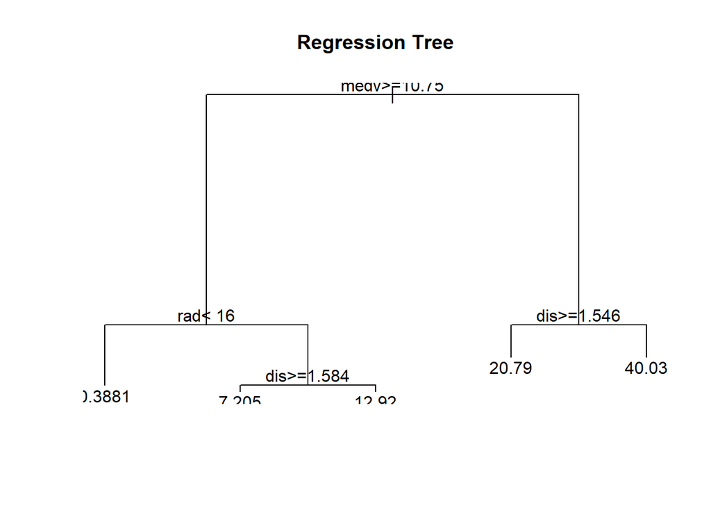

```r
plot(Boston_tree)
text(Boston_tree, pretty = 0)
title(main = "Regression Tree")
```

**Question 4 : re-plot the tree by using the rpart.plot18 packages (rpart.plot() and prp())**

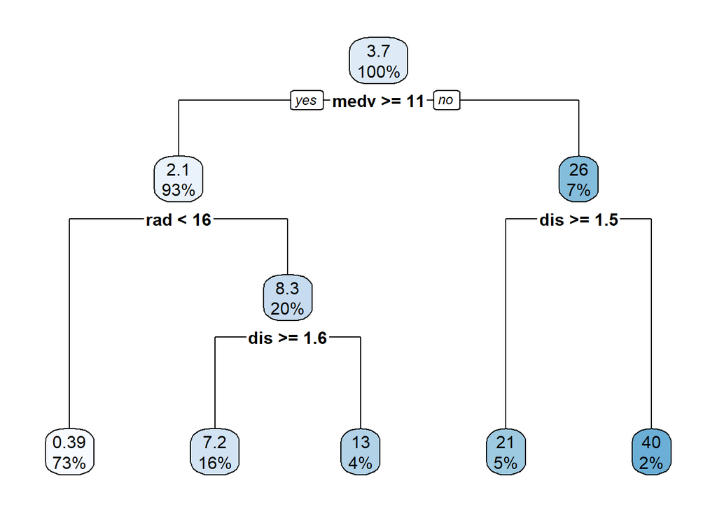

```r
library(rpart.plot)
rpart.plot(Boston_tree)
```

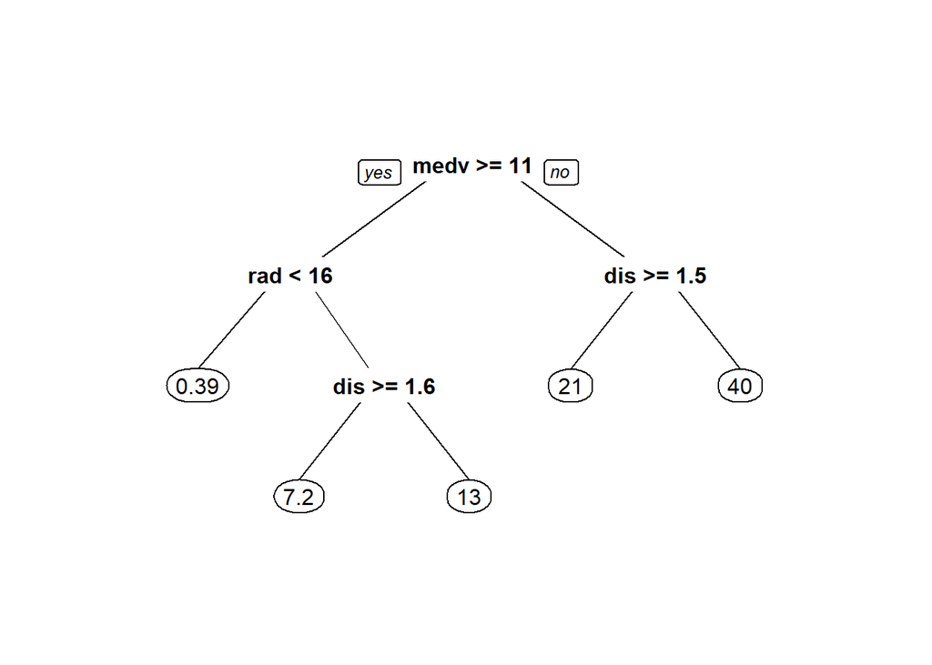

```r
prp(Boston_tree)
```

**Question 5 : Print the obtained tree and print its summary. Print the CP table using the printcp() function to see the cross validation results. Plot a comparison figure using the plotcp() function.**

```r
summary(Boston_tree)
```

```
## Call:
## rpart(formula = training_data)
##   n= 362
##
##           CP nsplit rel error    xerror      xstd
## 1 0.44522746      0 1.0000000 1.0083901 0.3297988
## 2 0.11630739      1 0.5547725 0.5879411 0.1773622
## 3 0.06131957      2 0.4384651 0.5775404 0.2297798
## 4 0.01207340      3 0.3771456 0.5966582 0.2302349
## 5 0.01000000      4 0.3650722 0.6036157 0.2302394
##
## Variable importance
##    medv     rad     tax     dis     nox   indus ptratio   lstat   black      rm
##      48      11      11       7       6       5       4       4       3       2
##
## Node number 1: 362 observations,    complexity param=0.4452275
##   mean=3.727283, MSE=83.99181
##   left son=2 (337 obs) right son=3 (25 obs)
##   Primary splits:
##       medv < 10.75   to the right, improve=0.4452275, (0 missing)
##       rad  < 16      to the left,  improve=0.3788094, (0 missing)
##       tax  < 567.5   to the left,  improve=0.3520241, (0 missing)
##       nox  < 0.651   to the left,  improve=0.3100984, (0 missing)
##       dis  < 1.80755 to the right, improve=0.2472505, (0 missing)
##   Surrogate splits:
##       black < 28.14   to the right, agree=0.934, adj=0.04, (0 split)
##       lstat < 25.545  to the left,  agree=0.934, adj=0.04, (0 split)
##
## Node number 2: 337 observations,    complexity param=0.1163074
##   mean=2.061707, MSE=14.79923
##   left son=4 (266 obs) right son=5 (71 obs)
##   Primary splits:
##       rad     < 16      to the left,  improve=0.7090611, (0 missing)
##       tax     < 567.5   to the left,  improve=0.6702107, (0 missing)
##       indus   < 16.57   to the left,  improve=0.4568272, (0 missing)
##       nox     < 0.651   to the left,  improve=0.3993327, (0 missing)
##       ptratio < 20.15   to the left,  improve=0.3625730, (0 missing)
##   Surrogate splits:
##       tax     < 567.5   to the left,  agree=0.991, adj=0.958, (0 split)
##       nox     < 0.651   to the left,  agree=0.896, adj=0.507, (0 split)
```

[output cut: 33 more lines]

```
##       lstat < 23.06   to the left,  agree=0.845, adj=0.214, (0 split)
##       medv  < 27.7    to the left,  agree=0.845, adj=0.214, (0 split)
##       rm    < 4.9345  to the right, agree=0.831, adj=0.143, (0 split)
##
## Node number 6: 18 observations
##   mean=20.79389, MSE=300.1252
##
## Node number 7: 7 observations
##   mean=40.02733, MSE=659.1227
##
## Node number 10: 57 observations
##   mean=7.204889, MSE=9.420415
##
## Node number 11: 14 observations
##   mean=12.91988, MSE=31.83271
```

```r
printcp(Boston_tree)
```

```
##
## Regression tree:
## rpart(formula = training_data)
##
## Variables actually used in tree construction:
## [1] dis  medv rad
##
## Root node error: 30405/362 = 83.992
##
## n= 362
##
##         CP nsplit rel error  xerror    xstd
## 1 0.445227      0   1.00000 1.00839 0.32980
## 2 0.116307      1   0.55477 0.58794 0.17736
## 3 0.061320      2   0.43847 0.57754 0.22978
## 4 0.012073      3   0.37715 0.59666 0.23023
## 5 0.010000      4   0.36507 0.60362 0.23024
```

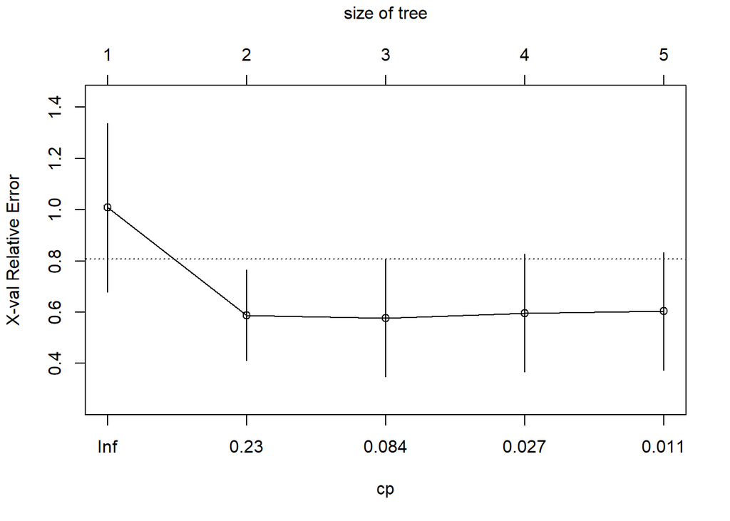

```r
plotcp(Boston_tree)
```

**Question 6 : write a function that returns the RMSE of two vectors**

```r
RMSE <- function(actual, predicted) {
  result = sqrt(mean(actual - predicted)^2)
  return(result)
}
```

**Question 7 : use the function predict() to predict the response on the test set then calculate the RMSE obtained with tree model.**

```r
prediction1 = predict(Boston_tree, newdata = testing_data)
RMSE(testing_data$medv, prediction1)
```

```
## [1] 19.51565
```

**Question 8 : fit a linear regression model on the training set then predict the response on the test set using the linear model. Calculate the RMSE and compare the performance of the tree and the linear regression.**

```r
linearmodel = lm(medv ~ ., data = training_data)
prediction2 = predict(linearmodel, newdata = testing_data)
RMSE(testing_data$medv, prediction2)
```

```
## [1] 0.7008524
```

The RMSE of the prediction with linear regression model is better than the RMsE of the precedent prediction in the question 7.

**Question 9 : let’s plot the actual (reality) response value against the predicted values for both models in order to compare them.**

```r
plot(prediction1, testing_data$medv)+abline(0,1,col="red")
```

```
## integer(0)
```

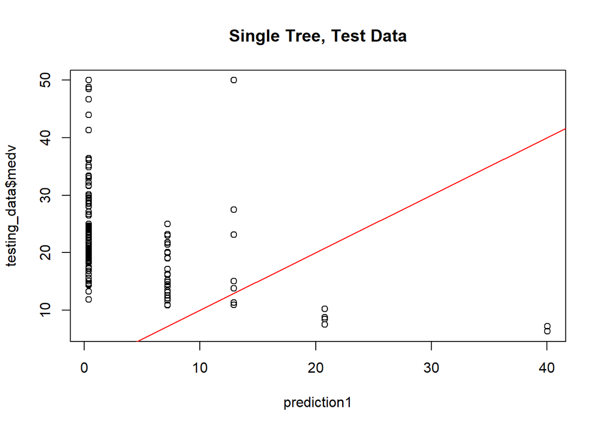

```r
title("Single Tree, Test Data")
```

```r
plot(prediction2, testing_data$medv)+abline(0,1,col="red")
```

```
## integer(0)
```

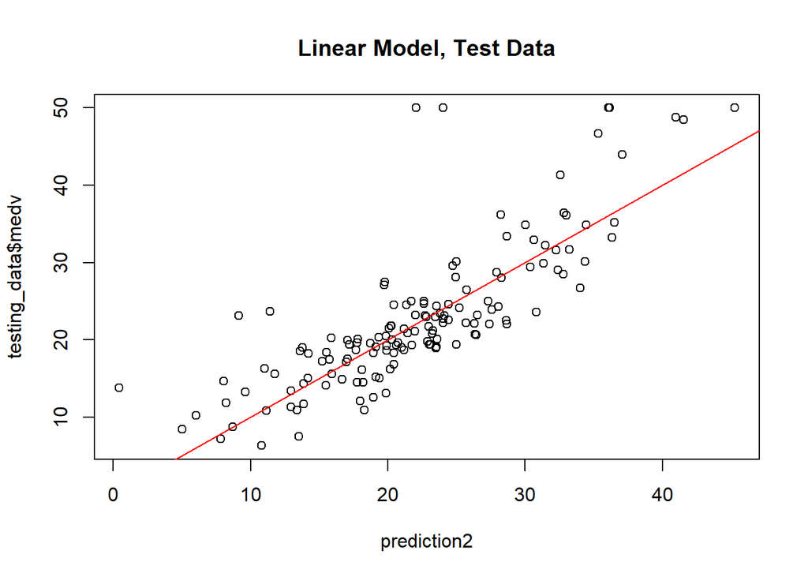

```r
title("Linear Model, Test Data")
```

**Question 10 : fit a bagged model, using the randomForest() function from the randomForest package with mtry = p (p : number of predictors).**

```r
library(randomForest)
bagged_model = randomForest(medv ~ ., mtry = ncol(training_data)-1, data = training_data)
```

**Question 11 : Predict the response on the test set using the bagging model and calculate the RMSE. Is the performance of the model better than linear regression or a simple tree ?**

```r
prediction3 = predict(bagged_model, newdata = testing_data)
RMSE(training_data$medv, prediction3)
```

```
## [1] 0.4967851
```

**Question 12 : Fit a random forest on the training set with mtry = p/3 (p : number of predictors) and compare its performance with the previous models by calculating the predictions and the RMSE.**

```r
set.seed(1)
random_forest = randomForest(medv ~ ., mtry = (ncol(training_data)-1)/3, data = training_data)
prediction4 = predict(random_forest, newdata = testing_data)
RMSE(training_data$medv,prediction4)
```

```
## [1] 0.3621537
```

In comparison with the previous models, the RMSE of this random forest model is the lowest. Therefore, the model in this question has the best performance.

**Question 13 : Use the function importance() from the randomForest package to see the most important predictors in the obtained random forest model.**

```r
importance(random_forest)
```

```
##         IncNodePurity
## crim        2075.8537
## zn           215.7028
## indus       2020.0565
## chas         294.0557
## nox         1721.2283
## rm          8243.4216
## age         1009.8283
## dis         1441.5405
## rad          252.3771
## tax         1071.3044
## ptratio     1942.8873
## black        591.7288
## lstat       8582.1285
```

**Question 14 : Plot the importance of the preidctors to the model using the varImpPlot() function.**

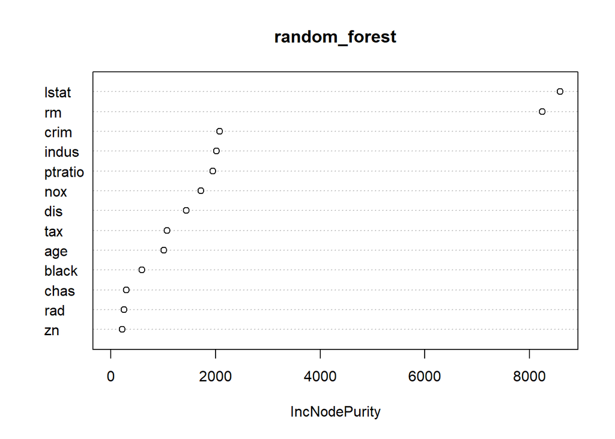

```r
varImpPlot(random_forest)
```

**Question 15 : Using the gbm() function like following, fit a boosted model on the training set. Then compare its performance with the previous models by calculating the predictions and the RMSE.**

```r
library(gbm)
set.seed(2)
boosted_model = gbm(medv ~ ., data = training_data, distribution = "gaussian", n.trees = 5000, interaction.depth = 4, shrinkage = 0.01)
prediction5 = predict(boosted_model, newdata = testing_data)
```

```
## Using 5000 trees...
```

```r
RMSE(training_data$medv, prediction5)
```

```
## [1] 0.36553
```

The boosted model has the same performance as the random forest model. Therefore the model is better than the single tree model, the linear model and the bagged model.

**Question 16 : Show the summary of the boosted model.**

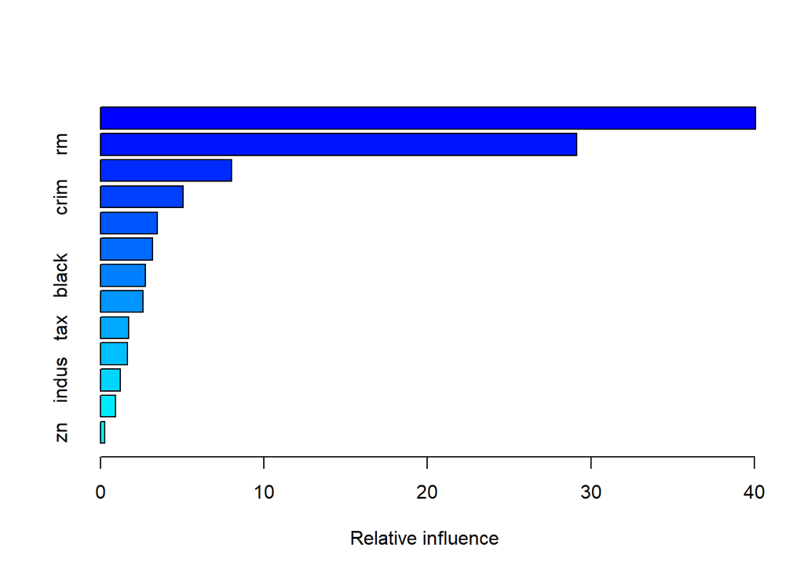

```
##             var    rel.inf
## lstat     lstat 40.0683889
## rm           rm 29.1373900
## dis         dis  8.0283466
## crim       crim  5.0505582
## nox         nox  3.4632527
## ptratio ptratio  3.1890532
## black     black  2.7333914
## age         age  2.5877262
## tax         tax  1.7292000
## chas       chas  1.6370109
## indus     indus  1.1974116
## rad         rad  0.9017954
## zn           zn  0.2764750
```

```r
summary(boosted_model)
```

The most important variable are lstat and rm.

**Question 17 : Construct a final plot to compare the four trained model.**

```r
par(mfrow=c(2,2))

plot(prediction1, testing_data$medv)+abline(0,1,col="red")
```

```
## integer(0)
```

```r
title("Single Tree, Test Data")

plot(prediction3, testing_data$medv)+abline(0,1,col="red")
```

```
## integer(0)
```

```r
title("Bagging, Test Data")

plot(prediction4, testing_data$medv)+abline(0,1,col="red")
```

```
## integer(0)
```

```r
title("Random Forest, Test Data")

plot(prediction5, testing_data$medv)+abline(0,1,col="red")
```

```
## integer(0)
```

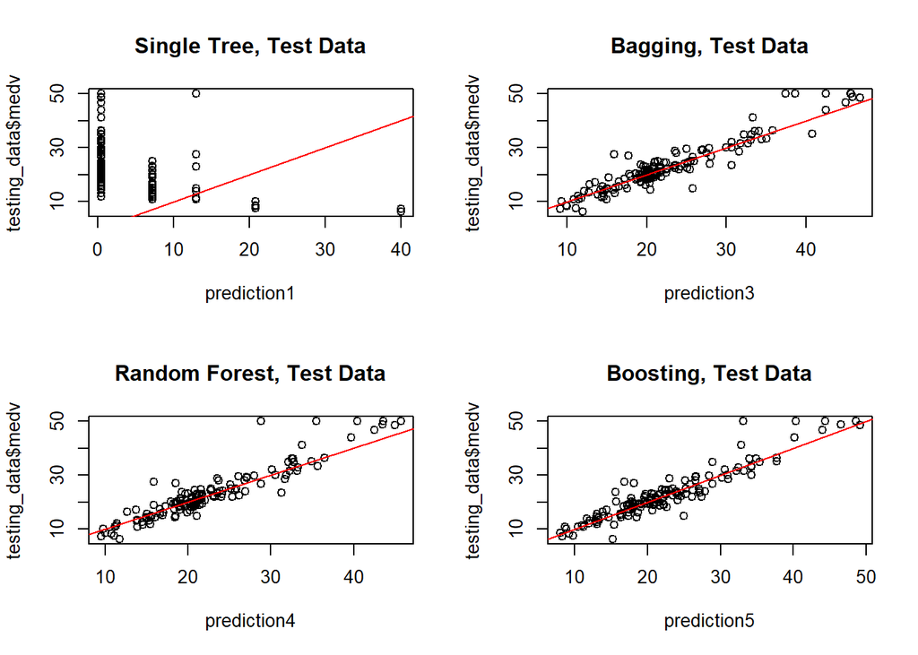

```r
title("Boosting, Test Data")
```

**Classification tree / Question 18**

```r
spam = read.csv("C:/Users/sandr/OneDrive/Documents/Scolarité/ESILV/M1 A4/S7/Machine Learning/TDs/Datas/spam.csv")

class(spam$spam)
```

```
## [1] "logical"
```

```r
spam$spam = factor(spam$spam)
class(spam$spam)
```

```
## [1] "factor"
```

```r
set.seed(3)
sample2 <- sample.split(spam, SplitRatio = 0.75)
training_spam <- subset(spam, sample==TRUE)
testing_spam <- subset(spam, sample==FALSE)
```

```r
accuracy <- function(actual, predicted){
  m <- table(actual,predicted)
  True_positive = m[1]
  False_negative = m[3]
  False_positive = m[2]
  True_negative = m[4]
  result = (True_positive + True_negative) / (True_positive + False_negative + False_positive + True_negative)
  return(result)
}

logistic_model = glm(spam ~ ., family = binomial, data = training_spam)
spam_prediction1 = predict(logistic_model, newdata = testing_spam)
#accuracy(training_spam$spam, spam_prediction1)

single_tree = rpart(training_spam)
spam_prediction2 = predict(single_tree, newdata = testing_spam)
#accuracy(training_spam$spam, spam_prediction2)

bagging_model = randomForest(spam ~ ., mtry = ncol(training_spam)-1, data = training_spam)
spam_prediction3 = predict(bagging_model, newdata = testing_spam)
#accuracy(training_spam$spam, spam_prediction3)

randomforest_model = randomForest(spam ~ ., mtry = (ncol(training_spam)-1)/3, data = training_spam)
spam_prediction4 = predict(randomforest_model, newdata = testing_spam)
#accuracy(training_spam$spam, spam_prediction4)

boosting_model = gbm(spam ~ ., data = training_spam, distribution = "gaussian", n.trees = 5000, interaction.depth = 4, shrinkage = 0.01)
spam_prediction5 = predict(boosting_model, newdata = testing_spam)
```

```
## Using 5000 trees...
```

```r
#accuracy(training_spam$spam, spam_prediction5)
```

**Tuning tree / Question 19 : Use the caret functions to tune your trained models.**

```r
library(caret)
set.seed(55)
fitControl = trainControl(method = "repeatedcv", number = 10, repeats = 10)
gbmFit = train(spam ~ ., data = training_spam, method = "gbm", trControl = fitControl, verbose = FALSE)
```